# MLandrum_Live_Session_4

Michael Landrum

9/23/2017

# 1

You will need to install the fivethirtyeight package to run this script. After doing so, use that library to find all the data sets. I manually counted until the 18th data set which was named “college_recent_grads”. Using vignette, I was able to track down the URL that had the article this information was used in.

The dimensions of the df are 173 x 21, and the column names are displayed below.

```r
#install.packages("fivethirtyeight")
library(fivethirtyeight)
df <- college_recent_grads

# vignette("fivethirtyeight", package = "fivethirtyeight")
# http://fivethirtyeight.com/features/the-economic-guide-to-picking-a-college-major/

dim(df)
```

```
## [1] 173  21
```

```r
colnames(df)
```

```
##  [1] "rank"                        "major_code"
##  [3] "major"                       "major_category"
##  [5] "total"                       "sample_size"
##  [7] "men"                         "women"
##  [9] "sharewomen"                  "employed"
## [11] "employed_fulltime"           "employed_parttime"
## [13] "employed_fulltime_yearround" "unemployed"
## [15] "unemployment_rate"           "p25th"
## [17] "median"                      "p75th"
## [19] "college_jobs"                "non_college_jobs"
## [21] "low_wage_jobs"
```

# 2

I’m sure there was a quicker way to finding the frequency of each category but I wanted to practice making loops. I created two empty vectors, one a character vector and one numeric. I iterated through each string in df$major_category and checked to see if it was already in the major vector. If it was, I added to the count of that major. If it was not, I created a new element in the major vector, and set the count to 1.

I used sum(count) to make sure it had 173 like our original data frame.

```r
#colnames(df)
ncol(df)
```

```
## [1] 21
```

```r
major <- character()
count <- numeric()
for(i in df$major_category){
  if( i %in% major ){
    x <- match(i, major)
    count[x] <- count[x] + 1
  } else{
    y <- length(major) + 1
    major[y] <- i
    count[y] <- 1
  }
}

major_count <- data.frame( major, count )
major_count
```

```
##                                  major count
## 1                          Engineering    29
## 2                             Business    13
## 3                    Physical Sciences    10
## 4                  Law & Public Policy     5
## 5              Computers & Mathematics    11
## 6      Agriculture & Natural Resources    10
## 7  Industrial Arts & Consumer Services     7
## 8                                 Arts     8
## 9                               Health    12
## 10                      Social Science     9
## 11              Biology & Life Science    14
## 12                           Education    16
## 13           Humanities & Liberal Arts    15
## 14            Psychology & Social Work     9
## 15         Communications & Journalism     4
## 16                   Interdisciplinary     1
```

```r
#sum(count)
```

A bar plot of the data is shown below. I removed the x-label due to it covering some of the majors. But you can unhide the comment to include it.

If you’d like to have a csv of this data, uncomment the final line.

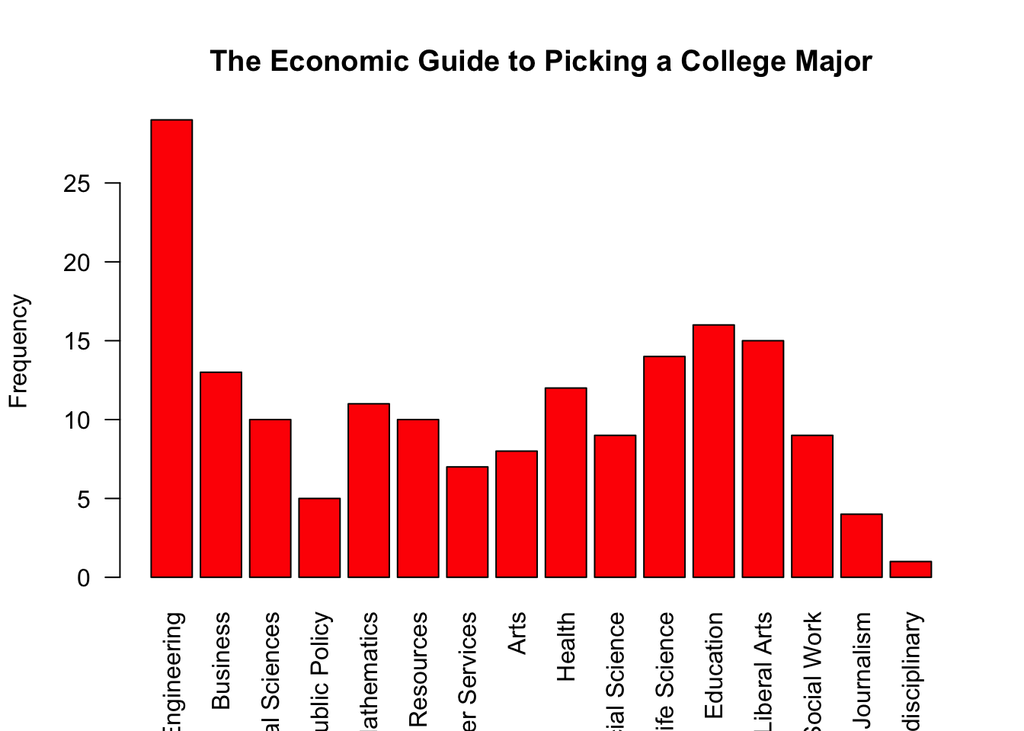

```r
par(las=2)
barplot(height = major_count$count, names.arg = major_count$major,
        main = "The Economic Guide to Picking a College Major",
        col = 2, ylab = "Frequency",
        #xlab = "College Majors"
        )
```

```r
#write.csv(major_count, file = "major_count.csv", row.names=FALSE)
```

3. My github repo can be found at https://github.com/mlandrum22/smuMSDS6306.git